# Make plots for Figure 1 and Figure S1

# 3 cell state UMAP

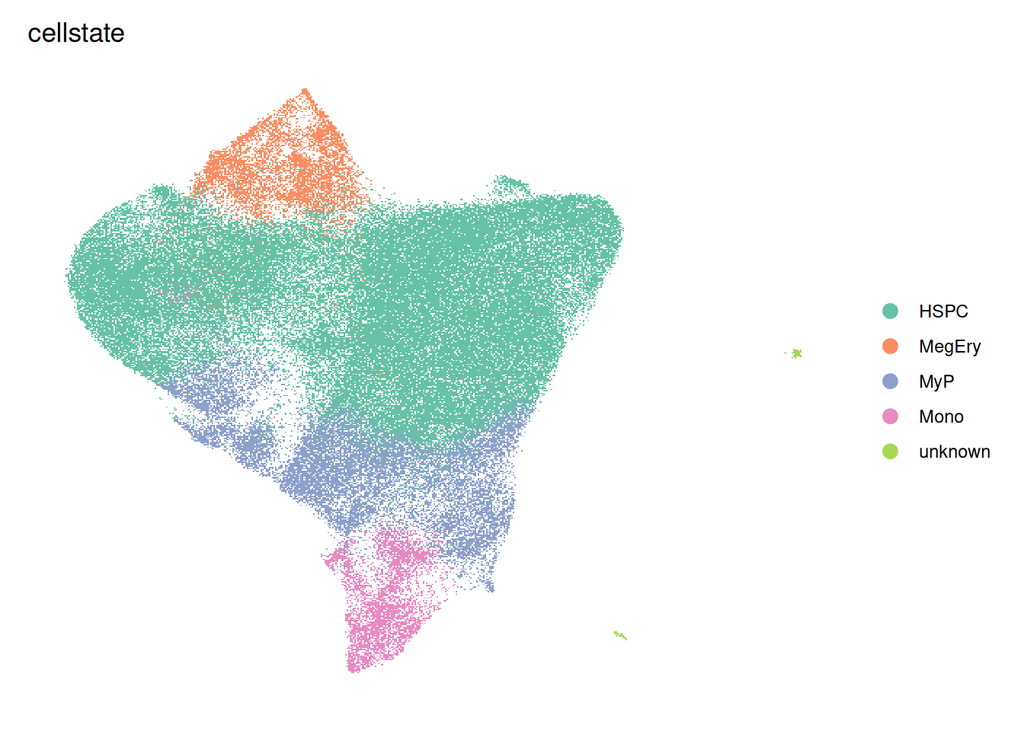

```r
cellstate_UMAP <- DimPlot(CRISPRi500_HSC_WTx,
                          reduction = "umap", group.by = 'cellstate') + scale_color_brewer(palette = "Set2") +
  theme_minimal() +
  theme(axis.title = element_blank(),
        axis.text = element_blank(),
        axis.ticks = element_blank(),
        panel.grid.major = element_blank(), panel.grid.minor = element_blank())

cellstate_UMAP
```

```r
# save plot
ggsave( filename = "manuscript/figs/umap_cellstate.pdf",
        plot     = cellstate_UMAP,
        width    = 7.8,
        height   = 6,
        units    = "in"
        )
```

# 4 marker gene expression UMAPs

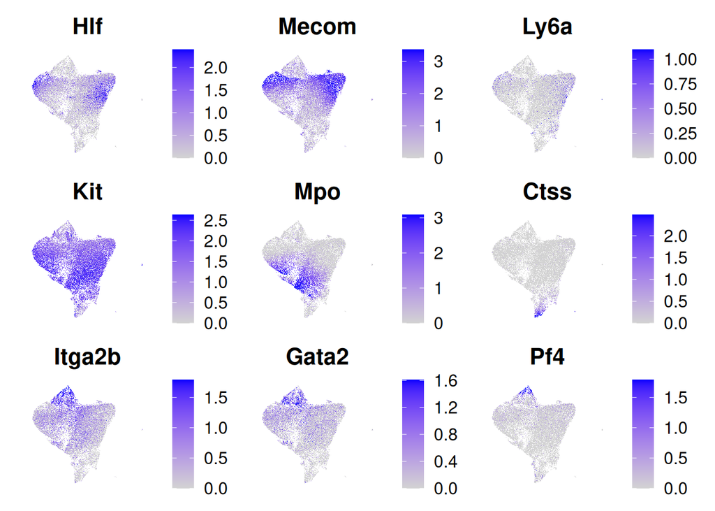

```r
DefaultAssay(CRISPRi500_HSC_WTx) <- "SCT"
marker_genes <- c("Hlf","Mecom","Ly6a","Kit","Mpo","Ctss","Itga2b","Gata2","Pf4")
marker_plots <- lapply(marker_genes, function(feature) {
  FeaturePlot(
    CRISPRi500_HSC_WTx,
    features = feature,
    max.cutoff = "q95"
  ) +
    theme(axis.line = element_blank(),
          axis.text = element_blank(),
          axis.ticks = element_blank(),
          axis.title = element_blank())
})

marker_gene_UMAP <- wrap_plots(marker_plots, ncol=3)
marker_gene_UMAP
```

```r
# save plot
# ggsave( filename = "manuscript/fig1/umaps_markergenes.pdf",
#         plot     = marker_gene_UMAP,
#         width    = 9,
#         height   = 10,
#         units    = "in"
#         )

ggsave( filename = "manuscript/fig1/umaps_markergenes_more.pdf",
        plot     = marker_gene_UMAP,
        width    = 13,
        height   = 10,
        units    = "in"
        )
```

# 5 cell cycle UMAP

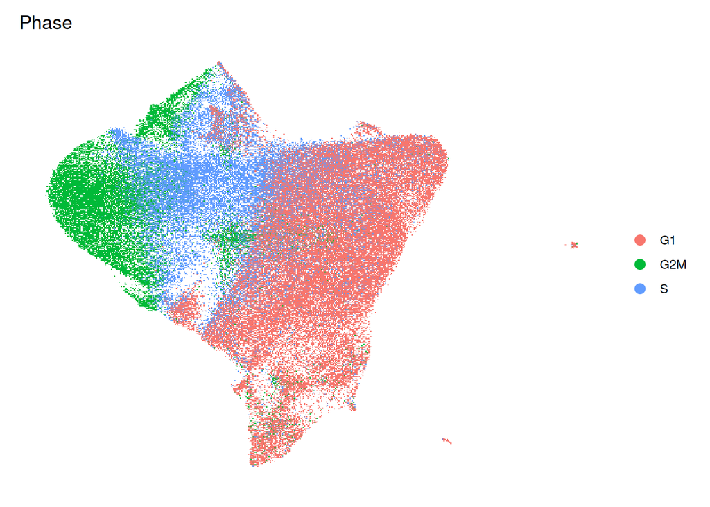

```r
#plot cell cycle scores
cellcycle_UMAP <- DimPlot(CRISPRi500_HSC_WTx,  reduction = "umap",
                          group.by = 'Phase', label=FALSE) +
  theme_minimal() +
  theme(axis.title = element_blank(),
        axis.text = element_blank(),
        axis.ticks = element_blank(),
        panel.grid.major = element_blank(), panel.grid.minor = element_blank())

cellcycle_UMAP
```

```r
# save plot
ggsave( filename = "manuscript/fig1/umap_cellcycle.pdf",
        plot     = cellcycle_UMAP,
        width    = 7.8,
        height   = 6,
        units    = "in"
        )
```

# 6 guide detection UMAP

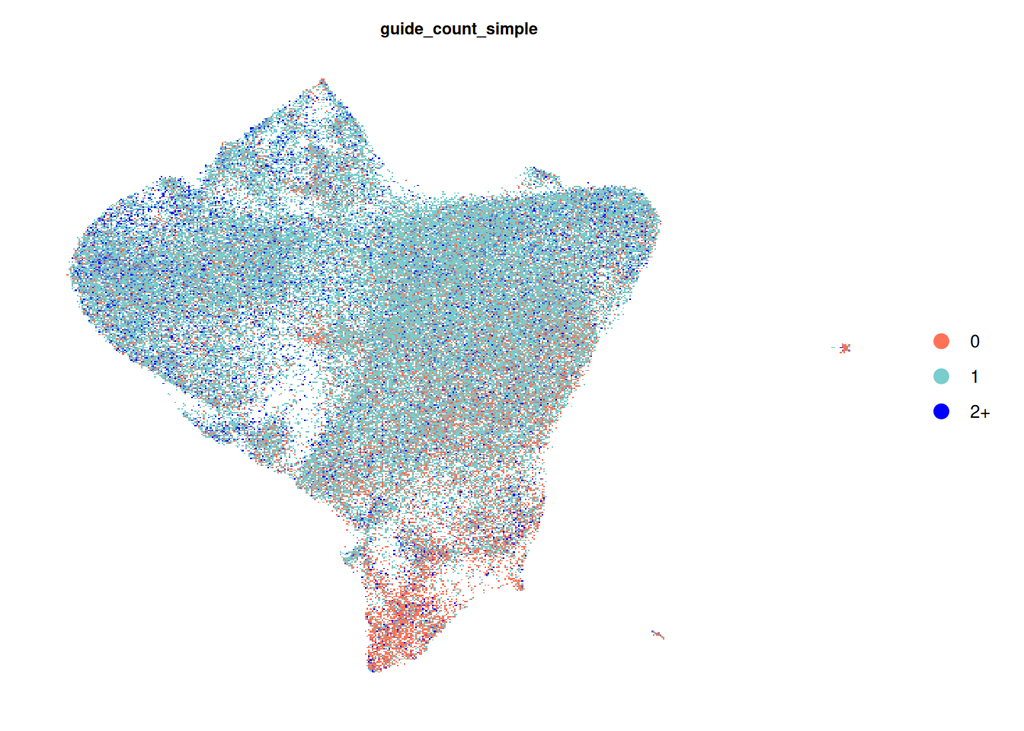

```r
## add guide count to seurat object
guides <- data.frame(CRISPRi500_HSC_WTx@meta.data[,c("guide_idents")])
rownames(guides) <- rownames(CRISPRi500_HSC_WTx@meta.data)
colnames(guides) <- "guide_id"
guides$guide_id[is.na(guides$guide_id)] <- ""

guides$guide_count <- sapply(strsplit(guides$guide_id, ", "), length) #count the number of guides in each row
summary_counts <- as.data.frame(table(guides$guide_count))

CRISPRi500_HSC_WTx$guide_count <- guides$guide_count #add to metadata

#plot 0, 1 and 2+ on umap
guides$guide_count_simple <- guides %>%
  mutate(guide_count = ifelse(guide_count > 1, "2+", as.character(guide_count)))

CRISPRi500_HSC_WTx$guide_count_simple <- guides$guide_count_simple[,2]

guide_count_umap <- DimPlot(CRISPRi500_HSC_WTx, reduction = "umap",
                            group.by = "guide_count_simple", label = FALSE)
guide_count_umap <- guide_count_umap + theme_minimal() +
        theme(axis.title = element_blank(), axis.text = element_blank(), axis.ticks = element_blank(),
              panel.grid.major = element_blank(), panel.grid.minor = element_blank(),
              plot.title = element_text(hjust = 0.5,  face = "bold", size = 8)) +
  scale_color_manual(values = c("coral1", "darkslategray3", "blue"))
guide_count_umap
```

```r
# save plot
ggsave( filename = "manuscript/figs/umap_guidedetection.pdf",
        plot     = guide_count_umap,
        width    = 7.8,
        height   = 6,
        units    = "in"
        )
```

# 7 guide detection barplot

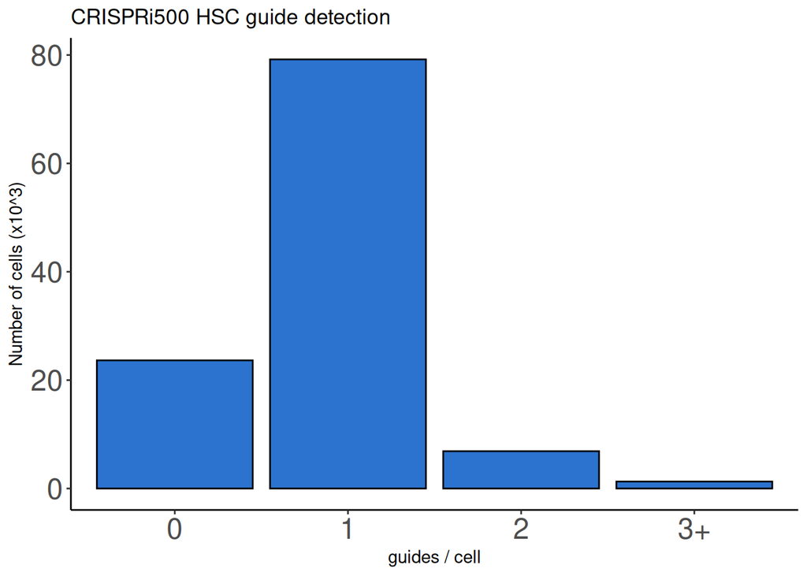

```r
## get and count guide_idents from seurat object
guides <- data.frame(CRISPRi500_HSC_WTx@meta.data[,c("guide_idents")])
rownames(guides) <- rownames(CRISPRi500_HSC_WTx@meta.data)
colnames(guides) <- "guide_id"
guides$guide_id[is.na(guides$guide_id)] <- ""

guides$guide_count <- sapply(strsplit(guides$guide_id, ", "), length) #count the number of guides in each row
summary_counts <- as.data.frame(table(guides$guide_count))

#group together 3+ and plot
colnames(summary_counts) <- c("num_guides","freq")
summary_counts$num_guides <- as.numeric(summary_counts$num_guides) - 1

summary_counts_grouped <- summary_counts %>%
  mutate(num_guides = ifelse(num_guides > 2, "3+", as.character(num_guides))) %>%
  group_by(num_guides) %>%
  summarise(freq = sum(freq), .groups = "drop")

guide_count_barplot <- ggplot(summary_counts_grouped, aes(x = factor(num_guides), y = freq/1000)) +
  geom_bar(stat = "identity", fill = "#2c73cf", color = "black") +
  labs(
    title = "CRISPRi500 HSC guide detection",
    x = "guides / cell",
    y = "Number of cells (x10^3)"
  ) +
  theme_classic() +
  theme(panel.grid.major = element_blank(), panel.grid.minor = element_blank(),
        axis.text.x = element_text(size = 18),
        axis.text.y = element_text(size = 18))
guide_count_barplot
```

```r
# save plot
ggsave( filename = "manuscript/figs/barplot_guidedetection.pdf",
        plot     = guide_count_barplot,
        width    = 4.5,
        height   = 6,
        units    = "in"
        )
```

```r
# guide count by cell state
guides_cellstate <- data.frame(CRISPRi500_HSC_WTx@meta.data[,c("guide_idents","cellstate")])
guides_cellstate$has_guide <- ifelse(is.na(guides_cellstate$guide_idents) |
                                     guides_cellstate$guide_idents == "", 0, 1)
percent_guides <- guides_cellstate %>%
  group_by(cellstate) %>%
  summarise(
    total_cells = n(),
    cells_with_guide = sum(has_guide),
    pct_with_guide = 100 * cells_with_guide / total_cells
  )
percent_guides
```

```
## # A tibble: 5 × 4
##   cellstate total_cells cells_with_guide pct_with_guide
##   <fct>           <int>            <dbl>          <dbl>
## 1 HSPC            80767            66659           82.5
## 2 MegEry           7321             6139           83.9
## 3 MyP             17640            12456           70.6
## 4 Mono             4961             2028           40.9
## 5 unknown           314               77           24.5
```

# 8 CRISPRi on-target repression

## 8.1 on-target by gene

- Use FindMarkers on the SCT-adjusted (vst) counts
- Save as dataframe

```r
# make metadata column of singletarget
CRISPRi500_HSC_WTx$singletarget <- sub("-.*", "", CRISPRi500_HSC_WTx$single_guides)
CRISPRi500_HSC_WTx$singletarget[grepl("^(ONE|NO)", CRISPRi500_HSC_WTx$singletarget)] <- "Non-targeting"

# get information on cells per gene perturbation
cells_per_gene_perturbation <- data.frame(table(CRISPRi500_HSC_WTx$singletarget))
colnames(cells_per_gene_perturbation) <- c("perturbation","nCells")
```

```r
#initialise empty de data frame
CRISPRi_ontarget_gene <- data.frame(matrix(nrow = 0, ncol = 8))
colnames(CRISPRi_ontarget_gene) <- c("perturbation","nCells_gene","nCells_NT","p_val","avg_log2FC","pct.1","pct.2","p_val_adj")

genes_to_test <- unique(CRISPRi500_HSC_WTx@meta.data$singletarget)
genes_to_test <- genes_to_test[genes_to_test != "Non-targeting"]
genes_to_test <- genes_to_test[genes_to_test != ""]
genes_to_test <- na.omit(genes_to_test)
# remove genes that dont work...
genes_to_test <- genes_to_test[genes_to_test != "Pou5f1"]
genes_to_test <- genes_to_test[genes_to_test != "Cdx4"]
genes_to_test <- genes_to_test[genes_to_test != "Sars"]

#on-target gene repression by target

for (gene_id in genes_to_test) {
    de <- Seurat::FindMarkers(CRISPRi500_HSC_WTx, group.by = "singletarget",
                    logfc.threshold = "0", min.pct = "0",
                    ident.1 = gene_id, ident.2 = "Non-targeting",
                    features = gene_id)
    de$perturbation <- gene_id
    de$nCells_gene <- subset(cells_per_gene_perturbation, perturbation == gene_id)$nCells
    de$nCellsNT <- subset(cells_per_gene_perturbation, perturbation == "Non-targeting")$nCells
    CRISPRi_ontarget_gene <- rbind(CRISPRi_ontarget_gene, de)
}

# add for final 3 targets: Pou5f1, Cdx4 are gone from the SCT assay because are there almost 0 counts from these genes
table(GetAssayData(CRISPRi500_HSC_WTx, assay = "RNA", slot = "counts")["Pou5f1", ])
table(GetAssayData(CRISPRi500_HSC_WTx, assay = "RNA", slot = "counts")["Cdx4", ])

# Sars is actually called Sars1
de <- Seurat::FindMarkers(CRISPRi500_HSC_WTx, group.by = "singletarget",
                          logfc.threshold = "0", min.pct = "0",
                          ident.1 = "Sars", ident.2 = "Non-targeting",
                          features = "Sars1")
de$perturbation <- "Sars1"
de$nCells_gene <- subset(cells_per_gene_perturbation, perturbation == gene_id)$nCells
de$nCellsNT <- subset(cells_per_gene_perturbation, perturbation == "Non-targeting")$nCells
CRISPRi_ontarget_gene <- rbind(CRISPRi_ontarget_gene, de)
```

```r
#write to file
write.csv(CRISPRi_ontarget_gene,
          file = "~/cluster/jbowness/CRISPRi500/HSC/clean_analysis/manuscript/int_files/CRISPRi500_HSC_ontarget_repression_gene.csv", row.names = FALSE)
```

## 8.2 on-target by guide

- generate table of on-target effects of guides using FindMarkers on SCT-adjusted counts
- FindMarkers only works with 3+ cells, so remove guides which have fewer than 3 cells

```r
# mutate to make a new metadata column single_guides_NT with "Non-targeting" for all controls
CRISPRi500_HSC_WTx$single_guides_NT <- CRISPRi500_HSC_WTx$single_guides
CRISPRi500_HSC_WTx$single_guides_NT[grepl("^(ONE-|NO-)", CRISPRi500_HSC_WTx$single_guides_NT)] <- "Non-targeting"

# get information on cells per guide
cells_per_guide <- data.frame(table(CRISPRi500_HSC_WTx$single_guides_NT))
colnames(cells_per_guide) <- c("guide","nCells")
```

```r
#guides to loop through - reduce to only those with 2+
cells_per_guide_sub <- cells_per_guide[cells_per_guide$nCells > 2,]
guides_to_test <- na.omit(cells_per_guide_sub$guide)
guides_to_test <- guides_to_test[guides_to_test != ""]
guides_to_test <- guides_to_test[!grepl("Non-targeting", guides_to_test)]

# associate guides with perturbed gene
guides_to_test <- as.data.frame(guides_to_test)
guides_to_test$perturbation <- sub("-CRISPRi-sgRNA-[123]$", "", guides_to_test$guides_to_test)
guides_to_test$perturbation[guides_to_test$perturbation == "Sars"] <- "Sars1"

guides_to_test <- subset(guides_to_test, perturbation != "Pou5f1")
guides_to_test <- subset(guides_to_test, perturbation != "Cdx4")

#initialise empty de data frame
CRISPRi_ontarget_guide <- data.frame(matrix(nrow = 0, ncol = 9))
colnames(CRISPRi_ontarget_guide) <- c("guide","perturbation","nCells_guide","nCells_NT","p_val","avg_log2FC","pct.1","pct.2","p_val_adj")

for (i in seq_len(nrow(guides_to_test))) {
  guide_id <- guides_to_test$guide[i]
  perturbation <- guides_to_test$perturbation[i]

  #test for on-target repression against "NO" and "ONE" NT controls
    de <- Seurat::FindMarkers(CRISPRi500_HSC_WTx, group.by = "single_guides_NT",
                    logfc.threshold = "0", min.pct = "0",
                    ident.1 = guide_id, ident.2 = "Non-targeting",
                    features = perturbation)
  # add to df
    de$guide <- guide_id
    de$perturbation <- perturbation
    de$nCells_guide <- subset(cells_per_guide_sub, guide == guide_id)$nCells
    de$nCellsNT <- subset(cells_per_guide_sub, guide == "Non-targeting")$nCells
    CRISPRi_ontarget_guide <- rbind(CRISPRi_ontarget_guide, de)
}
```

```r
#write to file
write.csv(CRISPRi_ontarget_guide, file = "~/cluster/jbowness/CRISPRi500/HSC/clean_analysis/manuscript/int_files/CRISPRi500_HSC_ontarget_repression_guide.csv", row.names = FALSE)
```

## 8.3 on-target plot all genes

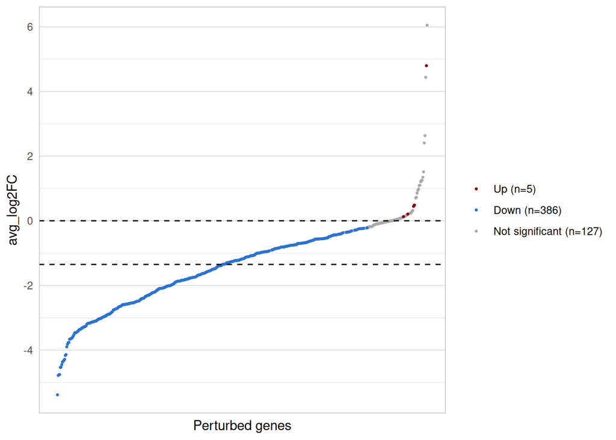

```r
# load on_target table
CRISPRi_ontarget_gene <- read_csv("~/cluster/jbowness/CRISPRi500/HSC/clean_analysis/manuscript/int_files/CRISPRi500_HSC_ontarget_repression_gene.csv")

CRISPRi_ontarget_gene$p_val_adj <- p.adjust(CRISPRi_ontarget_gene$p_val, method = "BH") # multiple testing correction
CRISPRi_ontarget_gene_sortLog2FC <- CRISPRi_ontarget_gene %>%
  arrange(avg_log2FC) %>%
  mutate(row_order = row_number(),
         sig = ifelse(p_val_adj < 0.05, "p < 0.05", "p >= 0.05"))

df <- CRISPRi_ontarget_gene_sortLog2FC %>%
  mutate(
    sig_dir = case_when(
      p_val_adj < 0.05 & avg_log2FC > 0 ~ "Up",
      p_val_adj < 0.05 & avg_log2FC < 0 ~ "Down",
      TRUE                          ~ "Not significant"
    )
  )

# counts for legend
n_up   <- sum(df$sig_dir == "Up", na.rm = TRUE)
n_down <- sum(df$sig_dir == "Down", na.rm = TRUE)
n_ns   <- sum(df$sig_dir == "Not significant", na.rm = TRUE)

legend_labels <- c(
  "Up"   = paste0("Up (n=", n_up, ")"),
  "Down" = paste0("Down (n=", n_down, ")"),
  "Not significant"  = paste0("Not significant (n=", n_ns, ")")
)

on_target_repression_all_genes <- ggplot(df, aes(x = row_order, y = avg_log2FC)) +
  # draw non-sig first (behind)
  geom_point(
    data = df %>% filter(sig_dir == "Not significant"),
    aes(color = sig_dir),
    size = 0.5
  ) +
  # then significant points on top
  geom_point(
    data = df %>% filter(sig_dir != "Not significant"),
    aes(color = sig_dir),
    size = 0.5
  ) +
  geom_hline(yintercept = mean(df$avg_log2FC, na.rm = TRUE), linetype = "dashed") +
  geom_hline(yintercept = 0, linetype = "dashed") +
  scale_y_continuous(
    breaks = function(x) seq(floor(min(x)), ceiling(max(x)), by = 2),  # ticks/labels every 2
    minor_breaks = function(x) seq(floor(min(x)), ceiling(max(x)), by = 1) # faint lines every 1
  ) +
  scale_color_manual(
    values = c("Up" = "darkred", "Down" = "#2c73cf", "Not significant" = "#a9aaab"),
    labels = legend_labels,
    breaks = c("Up", "Down", "Not significant")
  ) +
  labs(x = "Perturbed genes", y = "avg_log2FC", color = NULL) +
  theme_minimal() +
  theme(
    # horizontal grid lines: major + faint minor
    panel.grid.major.y = element_line(color = "grey85", linewidth = 0.3),
    panel.grid.minor.y = element_line(color = "grey90", linewidth = 0.2),

    # remove ALL vertical grid lines
    panel.grid.major.x = element_blank(),
    panel.grid.minor.x = element_blank(),

    # remove x axis ticks + labels (and keep no vertical axis line artifacts)
    axis.text.x  = element_blank(),
    axis.ticks.x = element_blank(),

    # optional: keep a border around the panel
    panel.border = element_rect(color = "grey", fill = NA),

    plot.title = element_text(hjust = 0.5)
  )
on_target_repression_all_genes
```

```r
# save to file
ggsave(
  filename = "/home/jbowness/cluster/jbowness/CRISPRi500/HSC/clean_analysis/manuscript/fig1/on_target_repression_all_genes.pdf",
  plot     = on_target_repression_all_genes,
  width    = 6,
  height   = 4,
  units    = "in"
)
```

## 8.4 on-target plot 5X genes

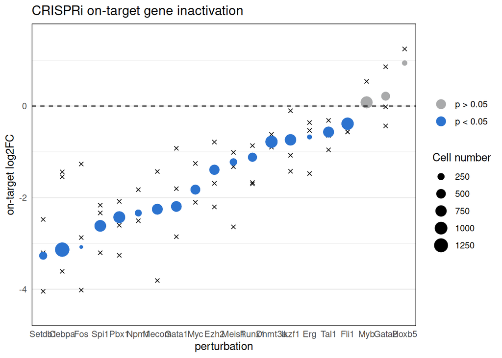

```r
# load results from guide and gene
CRISPRi_ontarget_gene <- read_csv("~/cluster/jbowness/CRISPRi500/HSC/clean_analysis/manuscript/int_files/CRISPRi500_HSC_ontarget_repression_gene.csv")
CRISPRi_ontarget_guide <- read_csv("~/cluster/jbowness/CRISPRi500/HSC/clean_analysis/manuscript/int_files/CRISPRi500_HSC_ontarget_repression_guide.csv")

#subset ontarget (by guide) to genes at 5X
CRISPRi_ontarget_5X <- subset(CRISPRi_ontarget_guide, perturbation %in% genes_at_5X)

# add overall log2fold per gene
CRISPRi_ontarget_gene_5X <- CRISPRi_ontarget_gene[,c("perturbation","avg_log2FC","nCells_gene","p_val")]
colnames(CRISPRi_ontarget_gene_5X) <- c("perturbation","avg_log2FC_gene","nCells_gene","p_val_gene")

CRISPRi_ontarget_5X <- merge(CRISPRi_ontarget_5X, CRISPRi_ontarget_gene_5X, by = "perturbation")

CRISPRi_ontarget_5X <- CRISPRi_ontarget_5X %>%
  arrange(avg_log2FC_gene) %>%
  mutate(perturbation = factor(perturbation, levels = unique(perturbation)))

# make plot
CRISPRi500_HSC_on_target_plot <- ggplot(CRISPRi_ontarget_5X) +
  geom_point(aes(x = perturbation, y = avg_log2FC), shape = 4) +
  geom_point(
    aes(
      x = perturbation,
      y = avg_log2FC_gene,
      color = p_val_gene < 0.05,
      size  = nCells_gene
    )
  ) +
  ylab("on-target log2FC") +
  ggtitle("CRISPRi on-target gene inactivation") +
  ylim(-4.5, 1.5) +
  geom_hline(yintercept = 0, linetype = "dashed") +
  theme_minimal() +
  theme(
    panel.grid.major.x = element_blank(),
    panel.border = element_rect(color = "black", fill = NA),
  ) +
  scale_color_manual(
    values = c(`TRUE` = "#2c73cf", `FALSE` = "#a9aaab"),
    labels = c(`TRUE` = "p < 0.05", `FALSE` = "p > 0.05"),
    name   = NULL
  ) +
  scale_size_continuous(name = "Cell number") +
  guides(
    color = guide_legend(order = 1, override.aes = list(size = 4)),
    size  = guide_legend(order = 2)
  )
CRISPRi500_HSC_on_target_plot
```

```r
ggsave(
  filename = "manuscript/fig1/on_target_repression_5X.pdf",
  plot     = CRISPRi500_HSC_on_target_plot,
  width    = 8,
  height   = 4,
  units    = "in"
)
```

## 8.5 on-target all order by detection and nCells

- In other whole-genome CRISPRi Perturb-seq data sets eg. Replogle (K562s), Zhu (T-cells), on-target repression depends on detection of the target gene. So we might expect worse on-target repression sensitivity for very low-expressed gene targets and/or where we have very few cells for the perturbation.

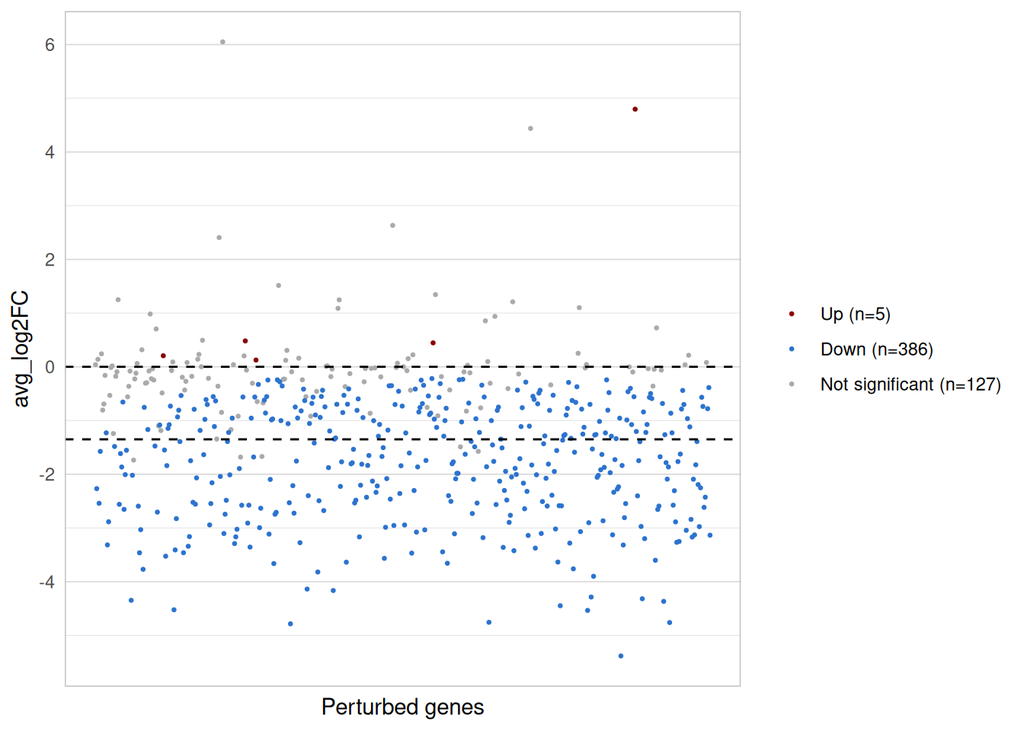

```r
# load on_target table by gene, and label significanc, as above ----
CRISPRi_ontarget_gene <- read_csv("~/cluster/jbowness/CRISPRi500/HSC/clean_analysis/manuscript/int_files/CRISPRi500_HSC_ontarget_repression_gene.csv")

CRISPRi_ontarget_gene$p_val_adj <- p.adjust(CRISPRi_ontarget_gene$p_val, method = "BH") # multiple testing correction
CRISPRi_ontarget_gene_sortLog2FC <- CRISPRi_ontarget_gene %>%
  arrange(avg_log2FC) %>%
  mutate(row_order = row_number(),
         sig = ifelse(p_val_adj < 0.05, "p < 0.05", "p >= 0.05"))

df <- CRISPRi_ontarget_gene_sortLog2FC %>%
  mutate(
    sig_dir = case_when(
      p_val_adj < 0.05 & avg_log2FC > 0 ~ "Up",
      p_val_adj < 0.05 & avg_log2FC < 0 ~ "Down",
      TRUE                          ~ "Not significant"
    )
  )

# make same plot as above but ordered by number of cells per gene perturbation ----
df$row_order_ncells <- rank(df$nCells_gene, ties.method = "first")
on_target_repression_all_genes_by_ncells <- ggplot(df, aes(x = row_order_ncells, y = avg_log2FC)) +
  # draw non-sig first (behind)
  geom_point(
    data = df %>% filter(sig_dir == "Not significant"),
    aes(color = sig_dir),
    size = 0.5
  ) +
  # then significant points on top
  geom_point(
    data = df %>% filter(sig_dir != "Not significant"),
    aes(color = sig_dir),
    size = 0.5
  ) +
  geom_hline(yintercept = mean(df$avg_log2FC, na.rm = TRUE), linetype = "dashed") +
  geom_hline(yintercept = 0, linetype = "dashed") +
  scale_y_continuous(
    breaks = function(x) seq(floor(min(x)), ceiling(max(x)), by = 2),  # ticks/labels every 2
    minor_breaks = function(x) seq(floor(min(x)), ceiling(max(x)), by = 1) # faint lines every 1
  ) +
  scale_color_manual(
    values = c("Up" = "darkred", "Down" = "#2c73cf", "Not significant" = "#a9aaab"),
    labels = legend_labels,
    breaks = c("Up", "Down", "Not significant")
  ) +
  labs(x = "Perturbed genes", y = "avg_log2FC", color = NULL) +
  theme_minimal() +
  theme(
    # horizontal grid lines: major + faint minor
    panel.grid.major.y = element_line(color = "grey85", linewidth = 0.3),
    panel.grid.minor.y = element_line(color = "grey90", linewidth = 0.2),

    # remove ALL vertical grid lines
    panel.grid.major.x = element_blank(),
    panel.grid.minor.x = element_blank(),

    # remove x axis ticks + labels (and keep no vertical axis line artifacts)
    axis.text.x  = element_blank(),
    axis.ticks.x = element_blank(),

    # optional: keep a border around the panel
    panel.border = element_rect(color = "grey", fill = NA),

    plot.title = element_text(hjust = 0.5)
  )
on_target_repression_all_genes_by_ncells
```

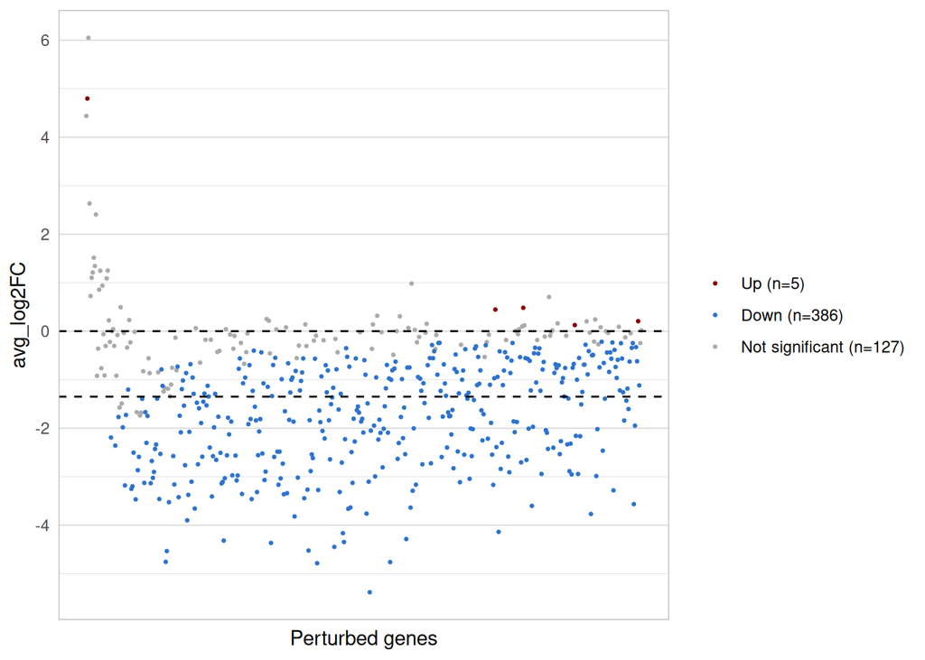

```r
# make same plot as above but ordered by detection of target gene in controls ----
df$row_order_detection <- rank(df$pct.2, ties.method = "first")
on_target_repression_all_genes_by_detection <- ggplot(df, aes(x = row_order_detection, y = avg_log2FC)) +
  # draw non-sig first (behind)
  geom_point(
    data = df %>% filter(sig_dir == "Not significant"),
    aes(color = sig_dir),
    size = 0.5
  ) +
  # then significant points on top
  geom_point(
    data = df %>% filter(sig_dir != "Not significant"),
    aes(color = sig_dir),
    size = 0.5
  ) +
  geom_hline(yintercept = mean(df$avg_log2FC, na.rm = TRUE), linetype = "dashed") +
  geom_hline(yintercept = 0, linetype = "dashed") +
  scale_y_continuous(
    breaks = function(x) seq(floor(min(x)), ceiling(max(x)), by = 2),  # ticks/labels every 2
    minor_breaks = function(x) seq(floor(min(x)), ceiling(max(x)), by = 1) # faint lines every 1
  ) +
  scale_color_manual(
    values = c("Up" = "darkred", "Down" = "#2c73cf", "Not significant" = "#a9aaab"),
    labels = legend_labels,
    breaks = c("Up", "Down", "Not significant")
  ) +
  labs(x = "Perturbed genes", y = "avg_log2FC", color = NULL) +
  theme_minimal() +
  theme(
    # horizontal grid lines: major + faint minor
    panel.grid.major.y = element_line(color = "grey85", linewidth = 0.3),
    panel.grid.minor.y = element_line(color = "grey90", linewidth = 0.2),

    # remove ALL vertical grid lines
    panel.grid.major.x = element_blank(),
    panel.grid.minor.x = element_blank(),

    # remove x axis ticks + labels (and keep no vertical axis line artifacts)
    axis.text.x  = element_blank(),
    axis.ticks.x = element_blank(),

    # optional: keep a border around the panel
    panel.border = element_rect(color = "grey", fill = NA),

    plot.title = element_text(hjust = 0.5)
  )
on_target_repression_all_genes_by_detection
```

# 9 essentiality analysis

## 9.1 statistical test

```r
# transform counts from vector into proportions
c500_vector_counts$c500_D_prop <- c500_vector_counts$c500_D_freq / sum(c500_vector_counts$c500_D_freq)
c500_vector_counts$c500_b_prop <- c500_vector_counts$c500_b_freq / sum(c500_vector_counts$c500_b_freq)
c500_vector_counts$guide <- gsub("_", "-", c500_vector_counts$guide)

# extract numbers of cells for each guide from seurat object
c500_HSPC_counts <- data.frame(table(CRISPRi500_HSC_WTx$single_guides))
colnames(c500_HSPC_counts) <- c("guide","ncells_HSPC")
c500_HSPC_counts <- subset(c500_HSPC_counts, guide != "")

# CRISPRi500 guides as proportions
CRISPRi500_proportions <- merge(c500_vector_counts, c500_HSPC_counts, by="guide", all=TRUE)
CRISPRi500_proportions$ncells_HSPC[is.na(CRISPRi500_proportions$ncells_HSPC)] <- 0
CRISPRi500_proportions$HSPC_prop <- CRISPRi500_proportions$ncells_HSPC / sum(CRISPRi500_proportions$ncells_HSPC)
cor(CRISPRi500_proportions$HSPC_prop, CRISPRi500_proportions$c500_D_prop)
```

```
## [1] 0.7843818
```

```r
## split treat each guide as a replicate for edgeR
CRISPRi500_proportions_splitguides <- CRISPRi500_proportions %>%
  select(c("gene","guide","c500_D_freq","ncells_HSPC"))  %>%
  mutate( guide_rep = paste0("guide", str_extract(guide, "\\d$")))

CRISPRi500_proportions2 <- CRISPRi500_proportions_splitguides %>%
  mutate(
    guide_rep = paste0("guide", str_extract(guide, "\\d$")),
    vec_guide1 = if_else(guide_rep == "guide1", c500_D_freq, NA_integer_),
    vec_guide2 = if_else(guide_rep == "guide2", c500_D_freq, NA_integer_),
    vec_guide3 = if_else(guide_rep == "guide3", c500_D_freq, NA_integer_)
  )  %>%
  mutate(
    guide_rep = paste0("guide", str_extract(guide, "\\d$")),
    HSPC_guide1 = if_else(guide_rep == "guide1", ncells_HSPC, NA_integer_),
    HSPC_guide2 = if_else(guide_rep == "guide2", ncells_HSPC, NA_integer_),
    HSPC_guide3 = if_else(guide_rep == "guide3", ncells_HSPC, NA_integer_)
  )
CRISPRi500_proportions2 <- CRISPRi500_proportions2 %>%
  select(c("gene","vec_guide1","vec_guide2","vec_guide3","HSPC_guide1","HSPC_guide2","HSPC_guide3"))

CRISPRi500_proportions_splitguides <- CRISPRi500_proportions2 %>%
  group_by(gene) %>%
  summarise(
    vec_guide1 = sum(vec_guide1, na.rm = TRUE),
    vec_guide2 = sum(vec_guide2, na.rm = TRUE),
    vec_guide3 = sum(vec_guide3, na.rm = TRUE),
    HSPC_guide1 = sum(HSPC_guide1, na.rm = TRUE),
    HSPC_guide2 = sum(HSPC_guide2, na.rm = TRUE),
    HSPC_guide3 = sum(HSPC_guide3, na.rm = TRUE),
    .groups = "drop"
  )
rm(CRISPRi500_proportions2)

# make into matrix
CRISPRi500_proportions_splitguides_mat <- as.matrix(CRISPRi500_proportions_splitguides[, c("vec_guide1", "vec_guide2", "vec_guide3",
                                  "HSPC_guide1", "HSPC_guide2", "HSPC_guide3")])
rownames(CRISPRi500_proportions_splitguides_mat) <- CRISPRi500_proportions_splitguides$gene

# set conditions
group <- factor(rep(c("vec", "HSPC"), each = 3), levels = c("vec", "HSPC"))
pair <- factor(rep(c("guide1", "guide2", "guide3"), 2))  # repeated for vec and HSPC
# make dge object
dge <- DGEList(counts = CRISPRi500_proportions_splitguides_mat, group = group)
dge <- calcNormFactors(dge)
# set up paired design
design <- model.matrix(~pair + group)
# dispersion and fit model
dge <- estimateDisp(dge, design)
fit <- glmFit(dge, design)
lrt <- glmLRT(fit, coef = "groupHSPC")
# perform DE
results <- topTags(lrt, n = Inf)$table
results$FDR <- p.adjust(results$PValue, method = "BH")
results$signif <- results$PValue < 0.01
```

## 9.2 volcano of EdgeR results

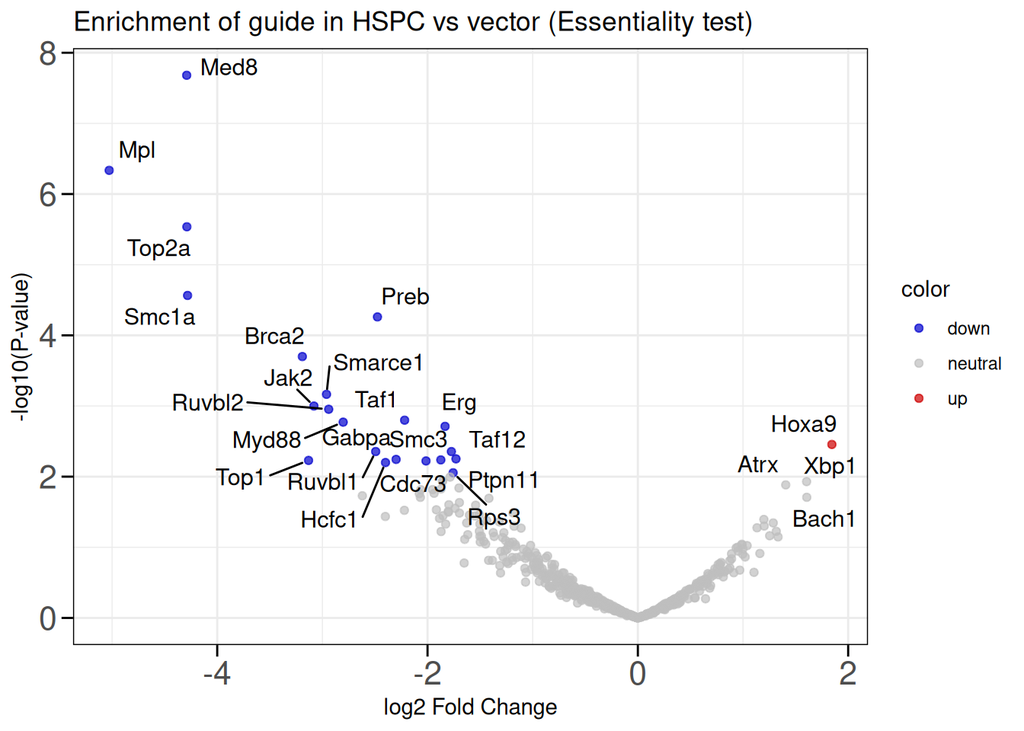

```r
# Convert results to a data frame if not already
results$gene <- rownames(results)

# Add -log10(p-value) for plotting
results$logP <- -log10(results$PValue)
results$color <- NULL
results <- results %>%
  mutate(color = case_when(
    signif == T & logFC > 1  ~ "up",
    signif == T & logFC < -1  ~ "down",
    signif == F ~ "neutral"
  ))

# volcano plot - with gene search?
essentiality_volcano <- ggplot(results, aes(x = logFC, y = logP, color = color, text = gene)) +
  geom_point(alpha = 0.7) +
  scale_color_manual(values = c("up" = "red3", "down" = "blue3", "neutral" = "gray")) +
     geom_text_repel(
       data = subset(results, PValue < 0.01 | logFC > 1.4),
       aes(label = gene),
       color = "black",
       size = 4,
       max.overlaps = Inf,
       box.padding = 0.35,
       point.padding = 0.3 ) +
  labs(
    title = "Enrichment of guide in HSPC vs vector (Essentiality test)",,
    x = "log2 Fold Change",
    y = "-log10(P-value)"
  ) +
  theme_minimal() +
  theme(
    panel.border = element_rect(color = "black", fill = NA),
    axis.text.x = element_text(size = 16),
    axis.text.y = element_text(size = 16),
    axis.ticks = element_line(color = "black"),
    axis.ticks.length = unit(0.2, "cm")
  )

essentiality_volcano
```

```r
# save plot
ggsave(
  filename = "manuscript/figs/volcano_essentiality_analysis.pdf",
  plot     = essentiality_volcano,
  width    = 7,
  height   = 6,
  units    = "in"
)
```

## 9.3 barplot top essential genes

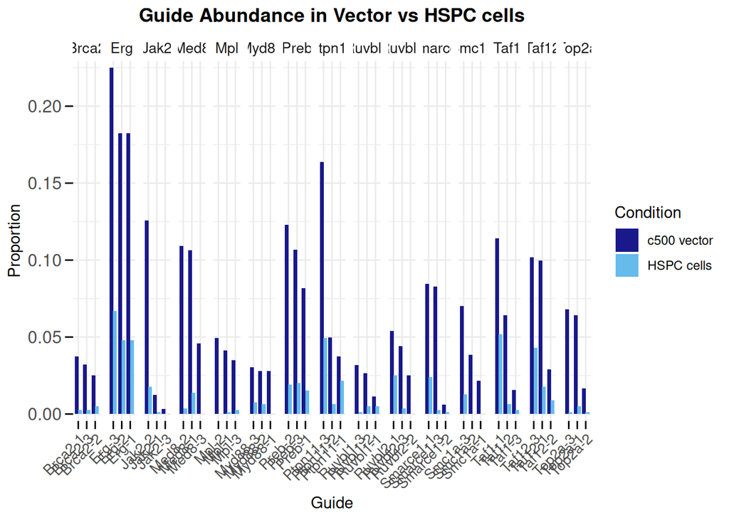

```r
## bar chart of top essential genes
genes_essential <- results %>%
  filter(logFC < 0) %>%
  arrange(PValue) %>%
  slice_head(n = 15)
genes_essential <- rownames(genes_essential)

CRISPRi500_proportions_essential <- subset(CRISPRi500_proportions, gene %in% genes_essential)

# make long format
CRISPRi500_proportions_essential_long <- CRISPRi500_proportions_essential %>%
  select(gene, guide, c500_D_prop, HSPC_prop) %>%
  pivot_longer(cols = c(c500_D_prop, HSPC_prop),
               names_to = "sample",
               values_to = "proportion")

# order guides
guide_order <- CRISPRi500_proportions_essential_long %>%
  filter(sample == "c500_D_prop") %>%
  arrange(gene, desc(proportion)) %>%
  group_by(gene) %>%
  mutate(ordered_guide = factor(guide, levels = unique(guide))) %>%
  ungroup() %>%
  select(gene, guide, ordered_guide)

# merge back into main data
CRISPRi500_proportions_essential_long <- CRISPRi500_proportions_essential_long %>%
  left_join(guide_order, by = c("gene", "guide"))

# plot vector vs num of HSPCs
essential_genes_barplot <- ggplot(
    subset(CRISPRi500_proportions_essential_long,sample %in% c("c500_D_prop", "HSPC_prop")),
    aes(x = ordered_guide, y = proportion*100, fill = sample)) +
  geom_bar(stat = "identity", position = position_dodge(width = 0.8), alpha = 0.9) +
  facet_wrap(~ gene, scales = "free_x", nrow = 1) +
  scale_fill_manual(values = c("c500_D_prop" = "navy", "HSPC_prop" = "#56B4E9"),
                    labels = c("c500 vector", "HSPC cells")) +
  labs(x = "Guide", y = "Proportion", fill = "Condition",
       title = "Guide Abundance in Vector vs HSPC cells") +
  theme_minimal() +
  theme(axis.text.x = element_text(angle = 45, size=10, hjust = 1),
        plot.title = element_text(hjust = 0.5, face = "bold"),
        axis.text.y = element_text(size = 12),
        axis.ticks = element_line(color = "black"),
        axis.ticks.length = unit(0.2, "cm"),
        strip.text = element_text(size = 10)
        )  +
  scale_x_discrete(
  labels = function(x) sub("^(.*)-CRISPRi-sgRNA-(\\d+)$", "\\1-\\2", x)
  ) +
  scale_y_continuous( expand = c(0.02,0)  )

essential_genes_barplot
```

```r
# save plot
ggsave(
  filename = "manuscript/figs/barplot_essential_genes.pdf",
  plot     = essential_genes_barplot,
  width    = 12,
  height   = 4,
  units    = "in"
)
```

## 9.4 barplot top “growth advantage” genes

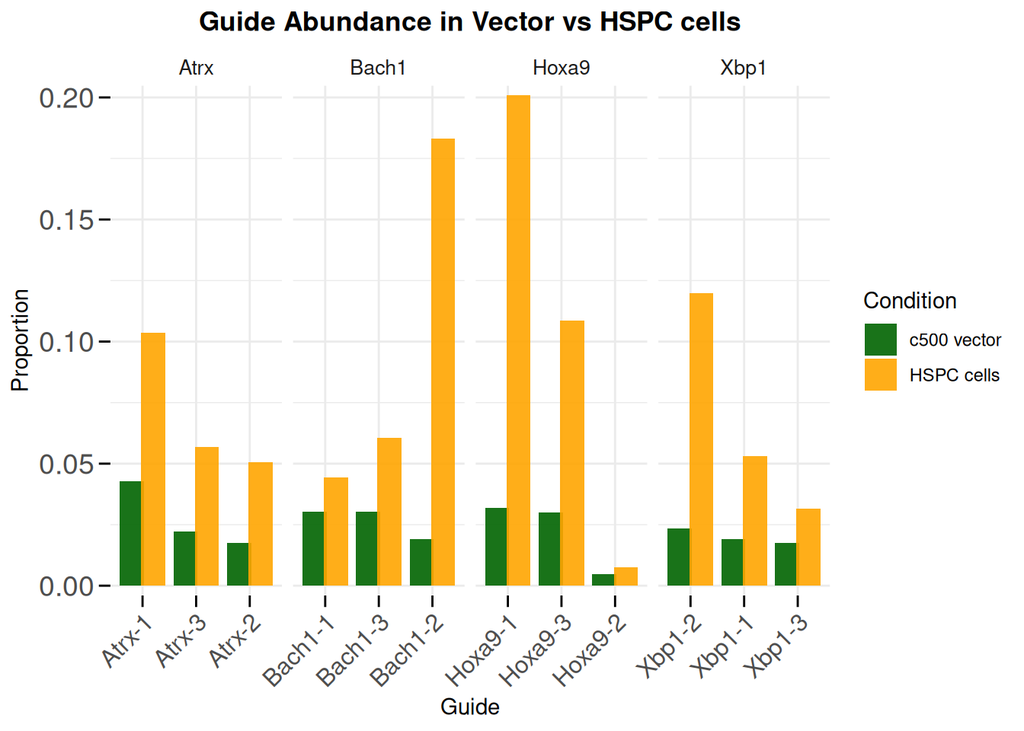

```r
## bar chart of top essential genes
genes_growth_ad <- results %>%
  filter(logFC > 0) %>%
  arrange(PValue) %>%
  slice_head(n = 4)
genes_growth_ad <- rownames(genes_growth_ad)

CRISPRi500_proportions_growth_ad <- subset(CRISPRi500_proportions, gene %in% genes_growth_ad)

# make long format
CRISPRi500_proportions_growth_ad_long <- CRISPRi500_proportions_growth_ad %>%
  select(gene, guide, c500_D_prop, HSPC_prop) %>%
  pivot_longer(cols = c(c500_D_prop, HSPC_prop),
               names_to = "sample",
               values_to = "proportion")

# order guides
guide_order <- CRISPRi500_proportions_growth_ad_long %>%
  filter(sample == "c500_D_prop") %>%
  arrange(gene, desc(proportion)) %>%
  group_by(gene) %>%
  mutate(ordered_guide = factor(guide, levels = unique(guide))) %>%
  ungroup() %>%
  select(gene, guide, ordered_guide)

# merge back into main data
CRISPRi500_proportions_growth_ad_long <- CRISPRi500_proportions_growth_ad_long %>%
  left_join(guide_order, by = c("gene", "guide"))

# plot vector vs num of HSPCs
growth_ad_genes_barplot <- ggplot(
    subset(CRISPRi500_proportions_growth_ad_long,sample %in% c("c500_D_prop", "HSPC_prop")),
    aes(x = ordered_guide, y = proportion*100, fill = sample)) +
  geom_bar(stat = "identity", position = position_dodge(width = 0.8), alpha = 0.9) +
  facet_wrap(~ gene, scales = "free_x", nrow = 1) +
  scale_fill_manual(values = c("c500_D_prop" = "darkgreen", "HSPC_prop" = "orange"),
                    labels = c("c500 vector", "HSPC cells")) +
  labs(x = "Guide", y = "Proportion", fill = "Condition",
       title = "Guide Abundance in Vector vs HSPC cells") +
  theme_minimal() +
  theme(axis.text.x = element_text(angle = 45, size=12, hjust = 1),
        plot.title = element_text(hjust = 0.5, face = "bold"),
        axis.text.y = element_text(size = 14),
        axis.ticks = element_line(color = "black"),
        axis.ticks.length = unit(0.2, "cm"),
        strip.text = element_text(size = 10)
        )  +
  scale_x_discrete(
  labels = function(x) sub("^(.*)-CRISPRi-sgRNA-(\\d+)$", "\\1-\\2", x),
  ) +
  scale_y_continuous( expand = c(0.02,0)  )

growth_ad_genes_barplot
```

```r
# save plot
ggsave(
  filename = "manuscript/figs/barplot_growth_advantage_genes.pdf",
  plot     = growth_ad_genes_barplot,
  width    = 5,
  height   = 4,
  units    = "in"
)
```

# 10 individual guides umaps

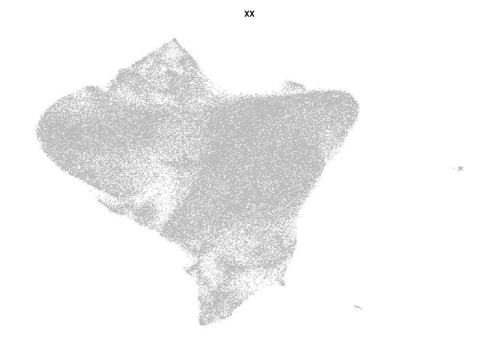

```r
# function to plot UMAP by guide
plot_umap_named_guide <- function(seurat_obj, guide_id, colour){
        seurat_obj$contains_target_guide <- grepl(guide_id, seurat_obj$guide_idents)
        #plot umap
        umap_plot <- DimPlot(seurat_obj,
                          reduction = "umap",
                          group.by = "contains_target_guide",
                          cols = c("grey", colour), label = FALSE)
        umap_plot <- umap_plot +
          geom_point(data = subset(umap_plot$data, contains_target_guide == TRUE),
                 aes(x = umap_1, y = umap_2),
                 color = colour, size = 0.5) +
      ggtitle(guide_id) +
      theme_minimal() +
      theme(legend.position = "none",
        axis.title = element_blank(), axis.text = element_blank(), axis.ticks = element_blank(),
        panel.grid.major = element_blank(), panel.grid.minor = element_blank(),
        plot.title = element_text(hjust = 0.5,  face = "bold", size = 8))
        return(umap_plot)
        }
#blank UMAP (for figures)
blank_umap <- plot_umap_named_guide(CRISPRi500_HSC_WTx,"XX","black")
blank_umap
```

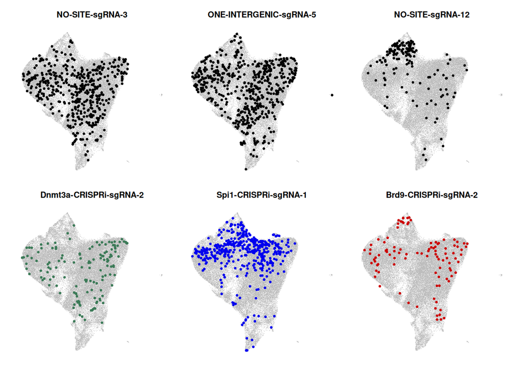

```r
NT3_umap <- plot_umap_named_guide(CRISPRi500_HSC_WTx,"NO-SITE-sgRNA-3","black")
NT12_umap <- plot_umap_named_guide(CRISPRi500_HSC_WTx,"NO-SITE-sgRNA-12","black")
NT10_umap <- plot_umap_named_guide(CRISPRi500_HSC_WTx,"NO-SITE-sgRNA-10","black")
OI5_umap <- plot_umap_named_guide(CRISPRi500_HSC_WTx,"ONE-INTERGENIC-sgRNA-5","black")

Dnmt3a_2_umap <- plot_umap_named_guide(CRISPRi500_HSC_WTx,"Dnmt3a-CRISPRi-sgRNA-2","#3B7A57")
Spi1_1_umap <- plot_umap_named_guide(CRISPRi500_HSC_WTx,"Spi1-CRISPRi-sgRNA-1","blue2")
Brd9_2_umap <- plot_umap_named_guide(CRISPRi500_HSC_WTx,"Brd9-CRISPRi-sgRNA-2","red3")

NT_plots_list <- list()
NT_plots_list[["NT3_umap"]] <- NT3_umap
#NT_plots_list[["NT10_umap"]] <- NT10_umap
NT_plots_list[["OI5_umap"]] <- OI5_umap
NT_plots_list[["NT12_umap"]] <- NT12_umap
NT_plots_list[["Dnmt3a_2_umap"]] <- Dnmt3a_2_umap
NT_plots_list[["Spi1_1_umap"]] <- Spi1_1_umap
NT_plots_list[["Brd9_2_umap"]] <- Brd9_2_umap


final_UMAP <- wrap_plots(plotlist = NT_plots_list, ncol = 3, nrow = 2)
final_UMAP
```

```r
# save plot
ggsave(
  filename = "~/cluster/jbowness/CRISPRi500/HSC/clean_analysis/manuscript/fig1/umap_blank.pdf",
  plot     = blank_umap,
  width    = 4,
  height   = 3.5,
  units    = "in"
)

ggsave(
  filename = "~/cluster/jbowness/CRISPRi500/HSC/clean_analysis/manuscript/fig1/umaps_guides.pdf",
  plot     = final_UMAP,
  width    = 8.8,
  height   = 5.5,
  units    = "in"
)
```

# 11 differential abundance non-targting guides

- Make the contingency table as ‘counts of test guide’ vs ‘counts of other control guides’

```r
# extract guide x celltype matrix
single_guide_by_cellstate <- CRISPRi500_HSC_WTx@meta.data[c("single_guides","singletarget","cellstate")]
single_guide_by_cellstate <- na.omit(single_guide_by_cellstate)
single_guide_by_cellstate <- subset(single_guide_by_cellstate, single_guides != "")

# remove "unknown" cellstate (not informative)
single_guide_by_cellstate <- subset(single_guide_by_cellstate, cellstate != "unknown")

# only NT controls
single_guide_by_cellstate_NT <- single_guide_by_cellstate %>% filter(singletarget == "Non-targeting")

# enrichment test for the cell states
results <- data.frame()
#testguide <- "NO-SITE-sgRNA-3"
#test_cellstate <- "MegEry"

for (testguide in unique(single_guide_by_cellstate_NT$single_guides)) {
  for (test_cellstate in unique(single_guide_by_cellstate_NT$cellstate)) {
    target_guide_by_cellstate <- single_guide_by_cellstate_NT %>%
      filter(cellstate == test_cellstate & single_guides == testguide)
    target_guide_not_cellstate <- subset(single_guide_by_cellstate_NT,
                                    !(cellstate == test_cellstate) & single_guides == testguide)
    #make contingency table
      guide_cellstate_count <- nrow(target_guide_by_cellstate)
      guide_notcellstate_count <- nrow(target_guide_not_cellstate)

      othercontrol_cellstate_count <- nrow(single_guide_by_cellstate_NT %>% filter(!(single_guides == testguide) & cellstate == test_cellstate) )
      othercontrol_notcellstate_count <- nrow(single_guide_by_cellstate_NT %>% filter(!(single_guides == testguide) & !(cellstate == test_cellstate )))

      contingency_mat <- matrix(c(guide_cellstate_count, guide_notcellstate_count,
                                  othercontrol_cellstate_count, othercontrol_notcellstate_count), ncol = 2)

      ## perform chi-squared test
      #chisq_res <- chisq.test(contingency_mat, correct = TRUE)
      #odds_ratio <- (guide_cellstate_count * othercontrol_notcellstate_count) / (guide_notcellstate_count * othercontrol_cellstate_count)
      #p_value <- chisq_res$p.value

      ## perform Fisher test
      fisher_res <- fisher.test(contingency_mat)
      odds_ratio <- fisher_res$estimate
      p_value <- fisher_res$p.value

    data <- data.frame(testguide, test_cellstate, odds_ratio, p_value)
    results <- rbind(results, data)
  }
}

results$p_adj_bh <- p.adjust(results$p_value, method = "BH")
results$significant <- results$p_adj_bh < 0.05

# set signficance minimum for plotting
results <- results %>% mutate(p_adj_bh = pmin(results$p_adj_bh, 40))
results$odds_ratio_log2 <- log2(results$odds_ratio)

# clean up Inf to log2FC of +/- 4
results <- results %>%
  mutate(odds_ratio_log2 = case_when(
    is.infinite(odds_ratio_log2) & odds_ratio_log2 > 0 ~ 4,
    is.infinite(odds_ratio_log2) & odds_ratio_log2 < 0 ~ -4,
    TRUE ~ odds_ratio_log2
  ))
```

## 11.1 make plot from testing for non-targeting

```r
#set levels (order)
cellstate_levels <- c("Mono", "MyP","HSPC","MegEry")
#make plot
NT_control_cellstate_bias_plot <- results %>%
  mutate(
    test_cellstate = factor(test_cellstate, levels = cellstate_levels),
    p_adj_cap = ifelse(p_adj_bh <= 0 | is.na(p_adj_bh), 1e-10, pmax(p_adj_bh, 1e-10)),
    x = -log10(p_adj_cap),
    point_class = dplyr::case_when(
      significant & odds_ratio_log2 > 0 ~ "sig_pos",
      significant & odds_ratio_log2 < 0 ~ "sig_neg",
      TRUE ~ "non_sig"
    ),
    hover = paste0(
      "guide: ", testguide,
      "<br>cellstate: ", test_cellstate,
      "<br>odds_ratio_log2: ", signif(odds_ratio_log2, 3),
      "<br>p_adj_bh: ", signif(p_adj_bh, 3),
      "<br>-log10(p_adj_cap): ", signif(x, 3)
    )
  ) %>%
  ggplot(aes(x = x, y = test_cellstate)) +
  geom_violin(aes(group = test_cellstate), trim = TRUE, alpha = 0.1) +
  geom_point(aes(color = point_class, text = hover),
             alpha = 0.8, size = 2,
             position = position_jitter(height = 0.12, width = 0)) +
  scale_color_manual(values = c(
    "non_sig" = "grey70",
    "sig_pos" = "red",
    "sig_neg" = "blue"
  )) +
  scale_x_continuous(
    breaks = function(lims) seq(floor(lims[1]), ceiling(lims[2]), by = 1),
    expand = expansion(mult = c(0.02, 0.05))
  ) +
  labs(
    x = "-log10(BH-adjusted p-value; min 1e-10)",
    y = "Cell state",
    color = ""
  ) +
  theme_classic()

subset(results, odds_ratio_log2 <= 0) %>%
  summary(significant)
```

```
##   testguide         test_cellstate       odds_ratio        p_value
##  Length:268         Length:268         Min.   :0.0000   Min.   :0.0000
##  Class :character   Class :character   1st Qu.:0.0000   1st Qu.:0.2248
##  Mode  :character   Mode  :character   Median :0.0000   Median :0.7212
##                                        Mean   :0.2566   Mean   :0.6282
##                                        3rd Qu.:0.4964   3rd Qu.:1.0000
##                                        Max.   :0.9956   Max.   :1.0000
##     p_adj_bh      significant     odds_ratio_log2
##  Min.   :0.0000   Mode :logical   Min.   :-4.147469
##  1st Qu.:0.6962   FALSE:244       1st Qu.:-4.000000
##  Median :1.0000   TRUE :24        Median :-4.000000
##  Mean   :0.7901                   Mean   :-2.651153
##  3rd Qu.:1.0000                   3rd Qu.:-1.010547
##  Max.   :1.0000                   Max.   :-0.006359
```

```r
subset(results, odds_ratio_log2 >= 0) %>%
  summary(significant)
```

```
##   testguide         test_cellstate       odds_ratio       p_value
##  Length:168         Length:168         Min.   :1.019   Min.   :0.00000
##  Class :character   Class :character   1st Qu.:1.378   1st Qu.:0.06311
##  Mode  :character   Mode  :character   Median :1.753   Median :0.31206
##                                        Mean   :  Inf   Mean   :0.36180
##                                        3rd Qu.:3.589   3rd Qu.:0.57806
##                                        Max.   :  Inf   Max.   :1.00000
##     p_adj_bh      significant     odds_ratio_log2
##  Min.   :0.0000   Mode :logical   Min.   :0.0270
##  1st Qu.:0.3228   FALSE:145       1st Qu.:0.4627
##  Median :0.8232   TRUE :23        Median :0.8096
##  Mean   :0.6543                   Mean   :1.3441
##  3rd Qu.:1.0000                   3rd Qu.:1.8436
##  Max.   :1.0000                   Max.   :5.5749
```

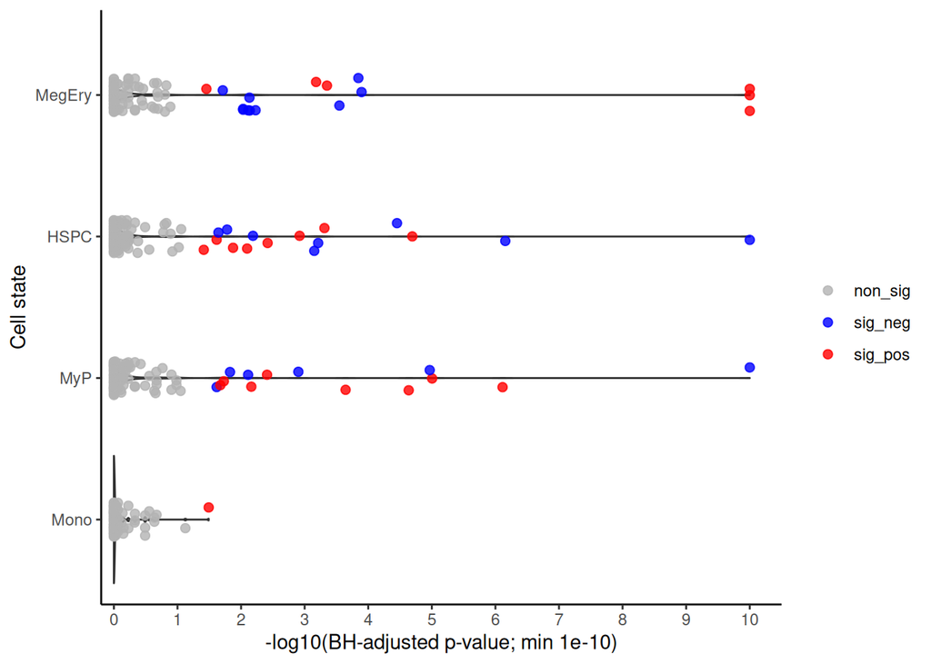

```r
NT_control_cellstate_bias_plot
```

```r
#ggplotly(NT_control_cellstate_bias_plot, tooltip = "text")
```

```r
ggsave( filename = "manuscript/fig1/NT_control_cellstate_bias_plot_fisher.pdf",
        plot     = NT_control_cellstate_bias_plot,
        width    = 8,
        height   = 5,
        units    = "in"
        )
```